# Lecture 10: Tidverse2

Kelly and Gallego

# Reshaping Datasets: `gather` and `spread`

Very often you have a dataset of one shape, and you want to somehow magically change it into a different shape. For example, you have this:

```
##                    mpg cyl disp
## Mazda RX4         21.0   6  160
## Mazda RX4 Wag     21.0   6  160
## Datsun 710        22.8   4  108
## Hornet 4 Drive    21.4   6  258
## Hornet Sportabout 18.7   8  360
## Valiant           18.1   6  225
```

… but you want this:

```
##      Mazda RX4 Mazda RX4 Wag Datsun 710 Hornet 4 Drive
## mpg         21            21       22.8           21.4
## cyl          6             6        4.0            6.0
## disp       160           160      108.0          258.0
##      Hornet Sportabout Valiant
## mpg               18.7    18.1
## cyl                8.0     6.0
## disp             360.0   225.0
```

… or this:

```
##                Model Measurement Value
## 1          Mazda RX4         mpg  21.0
## 2      Mazda RX4 Wag         mpg  21.0
## 3         Datsun 710         mpg  22.8
## 4     Hornet 4 Drive         mpg  21.4
## 5  Hornet Sportabout         mpg  18.7
## 6            Valiant         mpg  18.1
## 7          Mazda RX4         cyl   6.0
## 8      Mazda RX4 Wag         cyl   6.0
## 9         Datsun 710         cyl   4.0
## 10    Hornet 4 Drive         cyl   6.0
## 11 Hornet Sportabout         cyl   8.0
## 12           Valiant         cyl   6.0
## 13         Mazda RX4        disp 160.0
## 14     Mazda RX4 Wag        disp 160.0
## 15        Datsun 710        disp 108.0
## 16    Hornet 4 Drive        disp 258.0
## 17 Hornet Sportabout        disp 360.0
## 18           Valiant        disp 225.0
```

**R** – and particularly the tidyverse – is pretty good at reshaping dataframes once you get the hang of it.

- The most basic transformation for a dataframe is `t()` (in base-**R**), which just transposes rows into columns and vice-versa. That’s what we did from the first to the second examples above.
- Wide vs. Long. You’ve heard us talk about wide and long tables… in general, tidy data analysis likes long tables with very few columns (see the table directly above), and organizing data in this way makes it easy to do plotting in ggplot. BUT long tables don’t really make sense for humans to read off the screen (compare the first and third tables above… which would you rather read?)

It takes a while to get comfortable with these tidyverse commands, but they are super useful: `gather` makes a dataframe longer, and `spread` makes it wider. They are opposites of one another.

So:

```r
Cars <- head(mtcars[,1:3]) #make a small dataset to play with

Cars
```

```
##                    mpg cyl disp
## Mazda RX4         21.0   6  160
## Mazda RX4 Wag     21.0   6  160
## Datsun 710        22.8   4  108
## Hornet 4 Drive    21.4   6  258
## Hornet Sportabout 18.7   8  360
## Valiant           18.1   6  225
```

```r
#this has rownames, which we have to get rid of before we use `gather()`

Cars %>%
  rownames_to_column("Model") %>%    #here, move rownames to a column and call that column `Model`
  gather(#gather takes a few arguments, none of them intuitive:
    key = "ThingMeasured",  #the `key` will be the column header containing the newly organized info
    value = "Value",   #value is the measured value of the variable in the new column `ThingMeasured`
    -Model #and here, we're telling **R** NOT to gather the new column `Model` into `ThingMeasured`; we want it to be treated differently
  ) -> TidyCars  #create a new object called `TidyCars`

TidyCars
```

```
##                Model ThingMeasured Value
## 1          Mazda RX4           mpg  21.0
## 2      Mazda RX4 Wag           mpg  21.0
## 3         Datsun 710           mpg  22.8
## 4     Hornet 4 Drive           mpg  21.4
## 5  Hornet Sportabout           mpg  18.7
## 6            Valiant           mpg  18.1
## 7          Mazda RX4           cyl   6.0
## 8      Mazda RX4 Wag           cyl   6.0
## 9         Datsun 710           cyl   4.0
## 10    Hornet 4 Drive           cyl   6.0
## 11 Hornet Sportabout           cyl   8.0
## 12           Valiant           cyl   6.0
## 13         Mazda RX4          disp 160.0
## 14     Mazda RX4 Wag          disp 160.0
## 15        Datsun 710          disp 108.0
## 16    Hornet 4 Drive          disp 258.0
## 17 Hornet Sportabout          disp 360.0
## 18           Valiant          disp 225.0
```

```r
#then, to reverse this process, use `spread`:

spread(TidyCars, key = "ThingMeasured", value = "Value")
```

```
##               Model cyl disp  mpg
## 1        Datsun 710   4  108 22.8
## 2    Hornet 4 Drive   6  258 21.4
## 3 Hornet Sportabout   8  360 18.7
## 4         Mazda RX4   6  160 21.0
## 5     Mazda RX4 Wag   6  160 21.0
## 6           Valiant   6  225 18.1
```

Note that long tables are useful for ggplot, as mentioned. This is because the different values in the “key” column (here, called `ThingsMeasured`) lend themselves to facet wrapping (and, outside of ggplot, also to `group_by` and subsequent analyses).

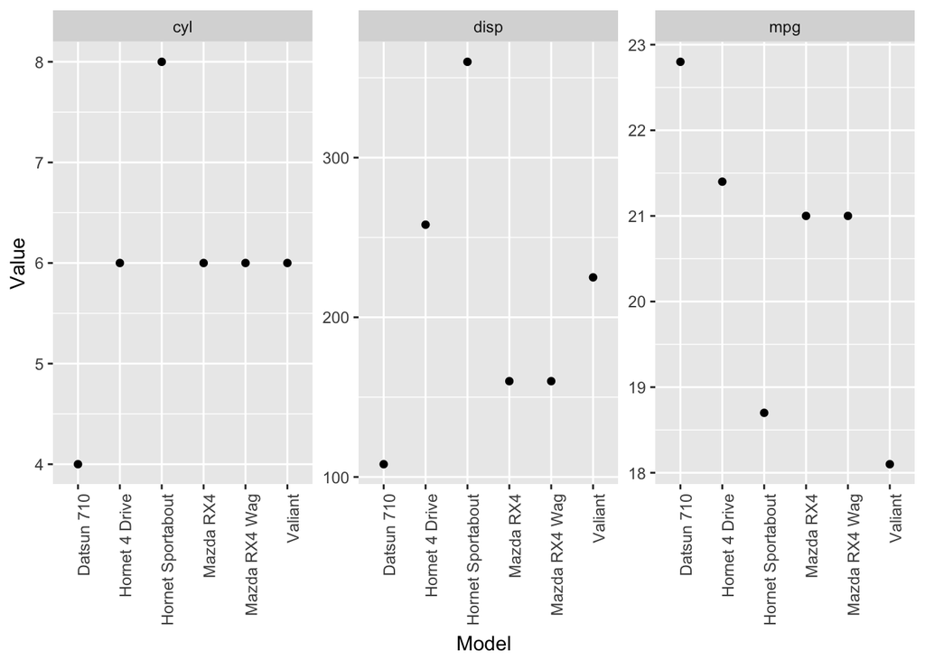

```r
ggplot(TidyCars, aes(x = Model, y = Value)) + geom_point() + facet_wrap(~ThingMeasured,
    scales = "free") + theme(axis.text.x = element_text(angle = 90, hjust = 1))  #rotate x-axis labels
```

# Merging and Joining

Another common requirement is merging two datasets together… for example, admissions data for grad school (where data from each year are on a separate spreadsheet), etc.

In one sense this can be a trivial task: where you are joining two dataframes with the exact same rows/columns, so you can just paste them together:

```r
# in base-R
rbind(Cars[1:3, ], Cars[4:6, ])
```

```
##                    mpg cyl disp
## Mazda RX4         21.0   6  160
## Mazda RX4 Wag     21.0   6  160
## Datsun 710        22.8   4  108
## Hornet 4 Drive    21.4   6  258
## Hornet Sportabout 18.7   8  360
## Valiant           18.1   6  225
```

```r
# in tidyverse:

bind_rows(Cars[1:3, ], Cars[4:6, ])  #note here if you want the model names, you'd have to preserve rownames with a function like `rownames_to_column()`
```

```
##    mpg cyl disp
## 1 21.0   6  160
## 2 21.0   6  160
## 3 22.8   4  108
## 4 21.4   6  258
## 5 18.7   8  360
## 6 18.1   6  225
```

But life is more complicated than that. Normally you have something like this:

```r
Cars1
```

```
##           Model mpg cyl
## 1     Mazda RX4  21   6
## 2 Mazda RX4 Wag  21   6
```

```r
Cars2
```

```
##               Model cyl disp
## 3        Datsun 710   4  108
## 4    Hornet 4 Drive   6  258
## 5 Hornet Sportabout   8  360
## 6           Valiant   6  225
```

```r
rbind(Cars1, Cars2)  #trying to do an rbind doesn't work because the column names are different... this is a safety check that makes sense.
```

```
## Error in match.names(clabs, names(xi)): names do not match previous names
```

```r
cbind(Cars1, Cars2)  #this weirdly does not give an error, but the output makes little sense... note that there are repeated entries
```

```
##           Model mpg cyl             Model cyl disp
## 1     Mazda RX4  21   6        Datsun 710   4  108
## 2 Mazda RX4 Wag  21   6    Hornet 4 Drive   6  258
## 3     Mazda RX4  21   6 Hornet Sportabout   8  360
## 4 Mazda RX4 Wag  21   6           Valiant   6  225
```

So what to do?

```r
merge(Cars1, Cars2, all = T)  #base-R uses the `merge` function
```

```
##               Model cyl mpg disp
## 1        Datsun 710   4  NA  108
## 2    Hornet 4 Drive   6  NA  258
## 3 Hornet Sportabout   8  NA  360
## 4         Mazda RX4   6  21   NA
## 5     Mazda RX4 Wag   6  21   NA
## 6           Valiant   6  NA  225
```

```r
full_join(Cars1, Cars2)  #tidyverse has a similar function `full_join`, and also `left_join`, `right_join`, `inner_join`, etc
```

```
##               Model mpg cyl disp
## 1         Mazda RX4  21   6   NA
## 2     Mazda RX4 Wag  21   6   NA
## 3        Datsun 710  NA   4  108
## 4    Hornet 4 Drive  NA   6  258
## 5 Hornet Sportabout  NA   8  360
## 6           Valiant  NA   6  225
```

Super useful. Note that it uses column names to decide what to merge. So the names have to be the same between datasets for this to work.

If you want to merge by rownames, create a new column from those names, and then use that column to merge the datasets.

## Joins with *key* columns: relational tables

Sometimes the two datasets you want to share don’t have the same columns: the information in both datasets is complementary. Let’s go back to the library `nycflights13`. It has a number of datasets:

- flights

```r
library(nycflights13)

flights
```

```
## # A tibble: 336,776 x 19
##     year month   day dep_time sched_dep_time dep_delay
##    <int> <int> <int>    <int>          <int>     <dbl>
##  1  2013     1     1      517            515         2
##  2  2013     1     1      533            529         4
##  3  2013     1     1      542            540         2
##  4  2013     1     1      544            545        -1
##  5  2013     1     1      554            600        -6
##  6  2013     1     1      554            558        -4
##  7  2013     1     1      555            600        -5
##  8  2013     1     1      557            600        -3
##  9  2013     1     1      557            600        -3
## 10  2013     1     1      558            600        -2
## # ... with 336,766 more rows, and 13 more variables:
## #   arr_time <int>, sched_arr_time <int>, arr_delay <dbl>,
## #   carrier <chr>, flight <int>, tailnum <chr>,
## #   origin <chr>, dest <chr>, air_time <dbl>,
## #   distance <dbl>, hour <dbl>, minute <dbl>,
## #   time_hour <dttm>
```

- airports

```r
airports
```

```
## # A tibble: 1,458 x 8
##    faa   name          lat    lon   alt    tz dst   tzone
##    <chr> <chr>       <dbl>  <dbl> <int> <dbl> <chr> <chr>
##  1 04G   Lansdowne …  41.1  -80.6  1044    -5 A     Americ…
##  2 06A   Moton Fiel…  32.5  -85.7   264    -6 A     Americ…
##  3 06C   Schaumburg…  42.0  -88.1   801    -6 A     Americ…
##  4 06N   Randall Ai…  41.4  -74.4   523    -5 A     Americ…
##  5 09J   Jekyll Isl…  31.1  -81.4    11    -5 A     Americ…
##  6 0A9   Elizabetht…  36.4  -82.2  1593    -5 A     Americ…
##  7 0G6   Williams C…  41.5  -84.5   730    -5 A     Americ…
##  8 0G7   Finger Lak…  42.9  -76.8   492    -5 A     Americ…
##  9 0P2   Shoestring…  39.8  -76.6  1000    -5 U     Americ…
## 10 0S9   Jefferson …  48.1 -123.    108    -8 A     Americ…
## # ... with 1,448 more rows
```

The information from both datasets is complementary, the only thing we need to combine both datasets is a common column that tells us which information from table2 can be joined with which row from table 1.

```r
joined.dataset <- left_join(flights, airports, by = c(origin = "faa"))
```

# `match` and `%in%`

While we’re at it, these are some other super useful things, although they aren’t in the tidyverse.

Suppose we have two vectors:

```r
v1 <- c(letters[1:10])

v2 <- c(letters[8:15])
```

Base-**R** has great ways of:

- finding out what elements of one vector are in another (`%in%`, which is a shorthand for another function, `is.element`), and
- reordering the elements of one vector to match those in another (`match`).

```r
match(v1, v2)  #NA means there is no match of v1 in v2.  A number is the index of the matching value... here, the 8th element of v1 is the 1st element of v2, for example.
```

```
##  [1] NA NA NA NA NA NA NA  1  2  3
```

```r
# note this is asymmetrical:
match(v2, v1)
```

```
## [1]  8  9 10 NA NA NA NA NA
```

```r
v1 %in% v2  #gives a logical vector: is each element of v1 included in v2?
```

```
##  [1] FALSE FALSE FALSE FALSE FALSE FALSE FALSE  TRUE  TRUE
## [10]  TRUE
```

```r
# this is the same as
is.element(v1, v2)
```

```
##  [1] FALSE FALSE FALSE FALSE FALSE FALSE FALSE  TRUE  TRUE
## [10]  TRUE
```

This is useful for, say, ordering rows of one dataset to match those in another dataset.

OK… digression over. Lastly:

# Filtering vs. Subsetting

In base-**R**, subsetting can be a bit awkward. Let’s say – in the `pirates` dataset – you want to see only the pirates that are older than 40.

```r
library(yarrr)

pirates[pirates$age > 40, ]  #one option; select all rows for which pirates$age > 40
```

```
##      id    sex age height weight headband college tattoos
## 5     5 female  41 157.85   58.4      yes   JSSFP       9
## 15   15 female  45 167.65   65.4      yes   JSSFP      14
## 95   95 female  45 148.20   54.2      yes   JSSFP      11
## 330 330 female  41 156.54   57.0      yes   JSSFP      10
## 639 639 female  41 165.10   64.5      yes   JSSFP      18
## 651 651 female  44 159.67   62.7      yes   JSSFP      14
## 656 656 female  41 172.17   68.8      yes   JSSFP      15
## 705 705 female  46 163.56   60.2      yes   JSSFP      10
## 774 774 female  43 169.37   62.0       no   JSSFP       6
## 800 800 female  41 169.78   71.8      yes   JSSFP      15
## 848 848 female  43 156.35   55.5      yes   JSSFP       9
##     tchests parrots favorite.pirate sword.type eyepatch
## 5         6       4            Hook    cutlass        1
## 15       70       0            Hook    cutlass        1
```

[output cut: 21 more lines]

```r
subset(pirates, pirates$age > 40)  #another option, same result
```

```
##      id    sex age height weight headband college tattoos
## 5     5 female  41 157.85   58.4      yes   JSSFP       9
## 15   15 female  45 167.65   65.4      yes   JSSFP      14
## 95   95 female  45 148.20   54.2      yes   JSSFP      11
## 330 330 female  41 156.54   57.0      yes   JSSFP      10
## 639 639 female  41 165.10   64.5      yes   JSSFP      18
## 651 651 female  44 159.67   62.7      yes   JSSFP      14
## 656 656 female  41 172.17   68.8      yes   JSSFP      15
## 705 705 female  46 163.56   60.2      yes   JSSFP      10
## 774 774 female  43 169.37   62.0       no   JSSFP       6
## 800 800 female  41 169.78   71.8      yes   JSSFP      15
## 848 848 female  43 156.35   55.5      yes   JSSFP       9
##     tchests parrots favorite.pirate sword.type eyepatch
## 5         6       4            Hook    cutlass        1
## 15       70       0            Hook    cutlass        1
```

[output cut: 21 more lines]

```r
# the tidyverse version of this is `filter`.  I find this confusing because you
# are filtering and KEEPING rows that meet a set of criteria, rather than
# ELIMINATING them.  But whatever.

pirates %>% filter(age > 40)  #this does the same thing as subsetting, but a bit more elegantly.  And very useful for piping the result on to something else!
```

```
##     id    sex age height weight headband college tattoos
## 1    5 female  41 157.85   58.4      yes   JSSFP       9
## 2   15 female  45 167.65   65.4      yes   JSSFP      14
## 3   95 female  45 148.20   54.2      yes   JSSFP      11
## 4  330 female  41 156.54   57.0      yes   JSSFP      10
## 5  639 female  41 165.10   64.5      yes   JSSFP      18
## 6  651 female  44 159.67   62.7      yes   JSSFP      14
## 7  656 female  41 172.17   68.8      yes   JSSFP      15
## 8  705 female  46 163.56   60.2      yes   JSSFP      10
## 9  774 female  43 169.37   62.0       no   JSSFP       6
## 10 800 female  41 169.78   71.8      yes   JSSFP      15
## 11 848 female  43 156.35   55.5      yes   JSSFP       9
##    tchests parrots favorite.pirate sword.type eyepatch
## 1        6       4            Hook    cutlass        1
## 2       70       0            Hook    cutlass        1
```

[output cut: 21 more lines]